# InviteBid

## 大类

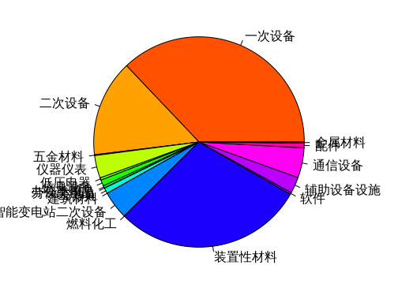

辽宁省物资采购以一次设备, 二次设备, 装置性材料为主,这3者占总采购金额的81.1739%。

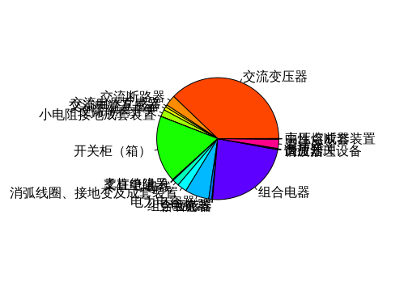

### 大类 一次设备

辽宁省物资采购中 一次设备 以 交流变压器 开关柜（箱） 电力电容器 组合电器 为主,这 4 者占 一次设备 总采购金额的 85.25 %。

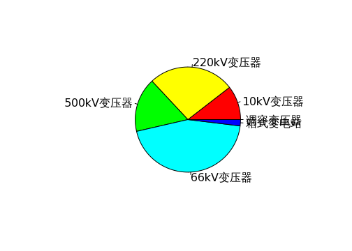

#### 中类 交流变压器

辽宁省物资采购中 交流变压器 以 220kV变压器 500kV变压器 66kV变压器 为主,这 3 者占 交流变压器 总采购金额的 87.57 %。

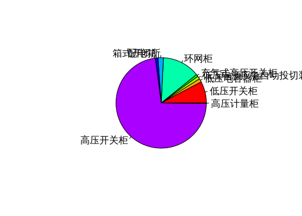

#### 中类 开关柜（箱）

辽宁省物资采购中 开关柜（箱） 以 环网柜 高压开关柜 为主,这 2 者占 开关柜（箱） 总采购金额的 86.14 %。

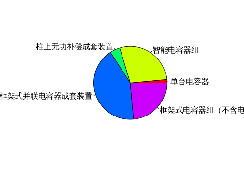

#### 中类 电力电容器

辽宁省物资采购中 电力电容器 以 智能电容器组 框架式并联电容器成套装置 框架式电容器组（不含电抗器） 为主,这 3 者占 电力电容器 总采购金额的 93.99 %。

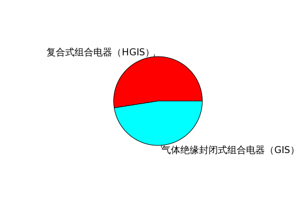

#### 中类 组合电器

辽宁省物资采购中 组合电器 以 复合式组合电器（HGIS） 气体绝缘封闭式组合电器（GIS） 为主,这 2 者占 组合电器 总采购金额的 100 %。

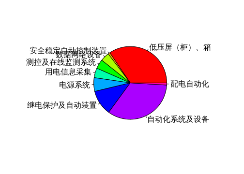

### 大类 二次设备

辽宁省物资采购中 二次设备 以 低压屏（柜）、箱 电源系统 继电保护及自动装置 自动化系统及设备 为主,这 4 者占 二次设备 总采购金额的 85.83 %。

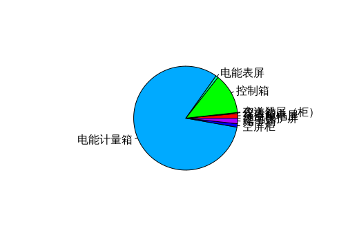

#### 中类 低压屏（柜）、箱

辽宁省物资采购中 低压屏（柜）、箱 以 电能计量箱 为主,这 1 者占 低压屏（柜）、箱 总采购金额的 82.07 %。

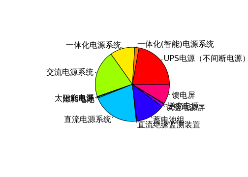

#### 中类 电源系统

辽宁省物资采购中 电源系统 以 UPS电源（不间断电源） 一体化电源系统 交流电源系统 直流电源系统 蓄电池组 为主,这 5 者占 电源系统 总采购金额的 87.01 %。

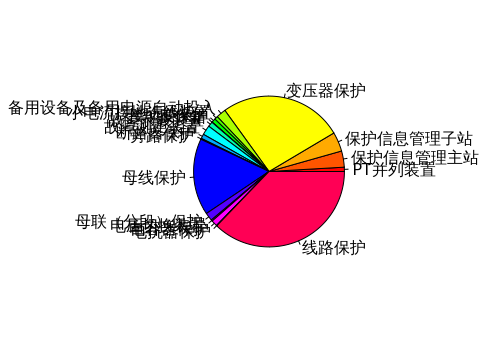

#### 中类 继电保护及自动装置

辽宁省物资采购中 继电保护及自动装置 以 变压器保护 母线保护 线路保护 为主,这 3 者占 继电保护及自动装置 总采购金额的 80.05 %。

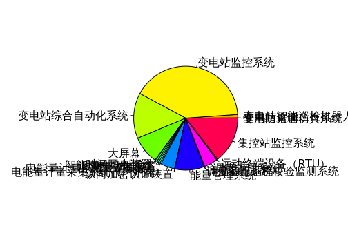

#### 中类 自动化系统及设备

辽宁省物资采购中 自动化系统及设备 以 变电站监控系统 变电站综合自动化系统 大屏幕 能量管理系统 集控站监控系统 为主,这 5 者占 自动化系统及设备 总采购金额的 87.5 %。

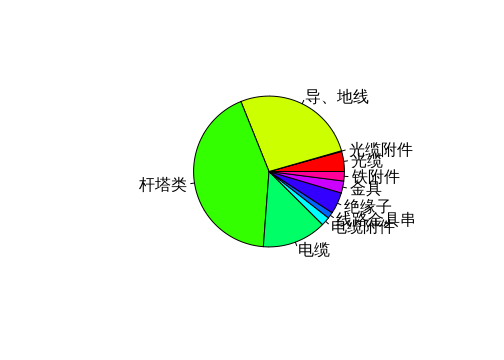

### 大类 装置性材料

辽宁省物资采购中 装置性材料 以 导、地线 杆塔类 电缆 为主,这 3 者占 装置性材料 总采购金额的 83.13 %。

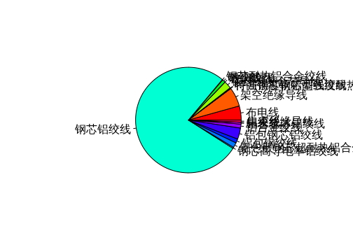

#### 中类 导、地线

辽宁省物资采购中 导、地线 以 架空绝缘导线 钢芯铝绞线 为主,这 2 者占 导、地线 总采购金额的 82.93 %。

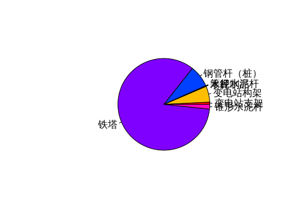

#### 中类 杆塔类

辽宁省物资采购中 杆塔类 以 铁塔 为主,这 1 者占 杆塔类 总采购金额的 83.96 %。

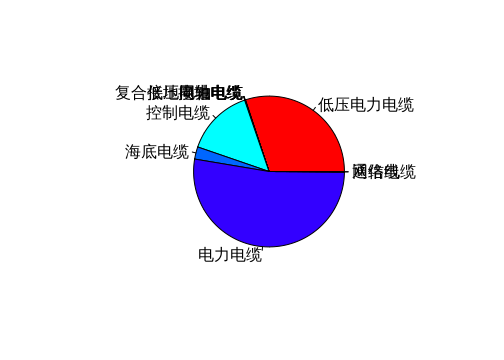

#### 中类 电缆

辽宁省物资采购中 电缆 以 低压电力电缆 电力电缆 为主,这 2 者占 电缆 总采购金额的 82.61 %。

重要的小类包括：220kV变压器, 500kV变压器, 66kV变压器, 环网柜, 高压开关柜, 智能电容器组, 框架式并联电容器成套装置, 框架式电容器组（不含电抗器）, 复合式组合电器（HGIS）, 气体绝缘封闭式组合电器（GIS）, 电能计量箱, UPS电源（不间断电源）, 一体化电源系统, 交流电源系统, 直流电源系统, 蓄电池组, 变压器保护, 母线保护, 线路保护, 变电站监控系统, 变电站综合自动化系统, 大屏幕, 能量管理系统, 集控站监控系统, 架空绝缘导线, 钢芯铝绞线, 铁塔, 低压电力电缆, 电力电缆，共29个小类,占采购总金额的59.8442%。

每小类分别比较价格

220kV变压器

重要的物资招标记录共9913条。

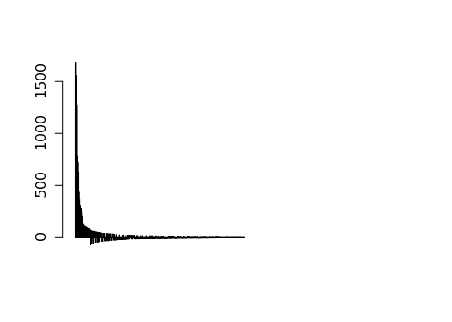

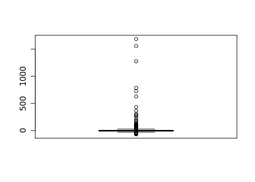

Min. 1st Qu. Median Mean 3rd Qu. Max. NA’s -69.1 -7.7 -2.2 28.7 7.1 1690.0 339

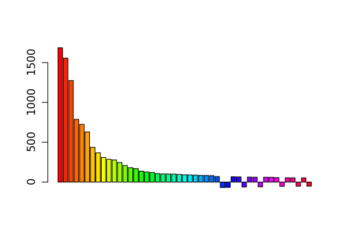

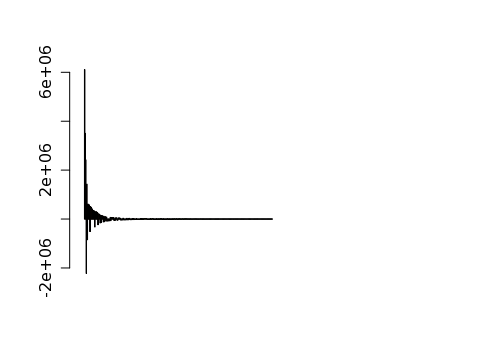

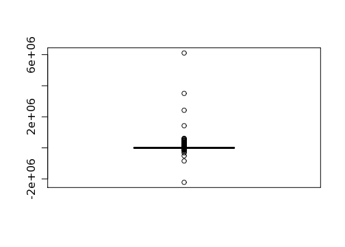

Min. 1st Qu. Median Mean 3rd Qu. Max. NA’s -2220000 -5720 -283 46300 2800 6110000 339

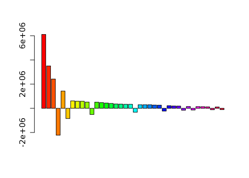

50%的物资价差集中在-7.696%—7.09%

变压器

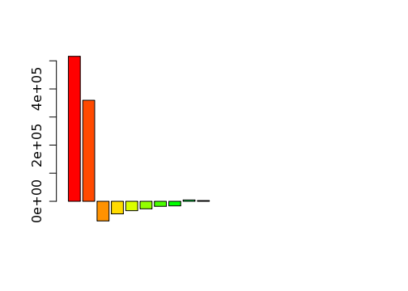

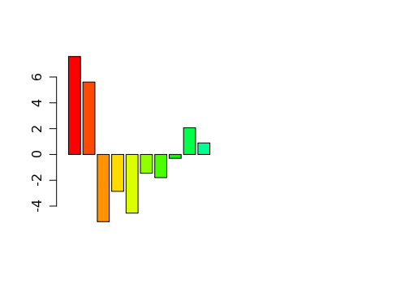

```
##                                               物料编码
##                                            "500037753"
##                                               物料描述
## "500kV单相油浸无励磁自耦变压器,334MVA,500/220/66,一体"
## [1] 5
##
##  Welch Two Sample t-test
##
## data:  as.numeric(data_byq$单价.不含税.) and as.numeric(data_byq_jl$单价.不含税.)
## t = 1.346, df = 2.682, p-value = 0.2809
## alternative hypothesis: true difference in means is not equal to 0
## 95 percent confidence interval:
##  -790540 1822540
## sample estimates:
## mean of x mean of y
##   7316000   6800000
##
##                                物料编码
##                             "500031221"
##                                物料描述
## "66kV油浸有载变压器,31.5MVA,66/10,一体"
## [1] 11
##
##  Welch Two Sample t-test
##
## data:  as.numeric(data_byq$单价.不含税.) and as.numeric(data_byq_jl$单价.不含税.)
## t = -2.54, df = 17.75, p-value = 0.02068
## alternative hypothesis: true difference in means is not equal to 0
## 95 percent confidence interval:
##  -127760  -12018
## sample estimates:
## mean of x mean of y
##   1271690   1341579
##
##                              物料编码
##                           "500031223"
##                              物料描述
## "66kV油浸有载变压器,40MVA,66/10,一体"
## [1] 63
##
```

[output cut: 97 more lines]

```
##                              "500057690"
##                                 物料描述
## "66kV油浸有载变压器,1000kVA,66/0.4,一体"
## [1] 3
##
##  Welch Two Sample t-test
##
## data:  as.numeric(data_byq$单价.不含税.) and as.numeric(data_byq_jl$单价.不含税.)
## t = 0.0299, df = 1.408, p-value = 0.9798
## alternative hypothesis: true difference in means is not equal to 0
## 95 percent confidence interval:
##  -592064  597449
## sample estimates:
## mean of x mean of y
##    305000    302308
```

```
## [1] "500037753"
##                                               物料描述
## "500kV单相油浸无励磁自耦变压器,334MVA,500/220/66,一体"
## [1] 4
##              单价.不含税. cuprice
## 单价.不含税.         1.00    0.71
## cuprice              0.71    1.00
##              单价.不含税. rbprice
## 单价.不含税.       1.0000 -0.8588
## rbprice           -0.8588  1.0000
##              单价.不含税.   curb
## 单价.不含税.       1.0000 0.6897
## curb               0.6897 1.0000
## [1] "500031233"
##                                     物料描述
## "220kV三相油浸有载变压器,240MVA,220/66,一体"
## [1] 5
##              单价.不含税. cuprice
## 单价.不含税.       1.0000  0.8252
## cuprice            0.8252  1.0000
##              单价.不含税. rbprice
## 单价.不含税.       1.0000  0.4655
## rbprice            0.4655  1.0000
##              单价.不含税.   curb
## 单价.不含税.       1.0000 0.7992
## curb               0.7992 1.0000
## [1] "500031221"
##                                物料描述
## "66kV油浸有载变压器,31.5MVA,66/10,一体"
## [1] 11
##              单价.不含税. cuprice
## 单价.不含税.       1.0000  0.5461
## cuprice            0.5461  1.0000
##              单价.不含税. rbprice
## 单价.不含税.        1.000   0.352
## rbprice             0.352   1.000
##              单价.不含税.   curb
## 单价.不含税.       1.0000 0.5633
## curb               0.5633 1.0000
## [1] "500031223"
```

[output cut: 218 more lines]

```
## 单价.不含税.            1   -1
## curb                   -1    1
## [1] "500116453"
##                                  物料描述
## "66kV油浸有载变压器,40MVA,66/10/6.3,一体"
## [1] 1
##              单价.不含税. cuprice
## 单价.不含税.           NA      NA
## cuprice                NA      NA
##              单价.不含税. rbprice
## 单价.不含税.           NA      NA
## rbprice                NA      NA
##              单价.不含税. curb
## 单价.不含税.           NA   NA
## curb                   NA   NA
```

data_byq_all$cu<-as.numeric(data_byq_all$cu)

data_byq_all<-data_byq_all[!is.na(data_byq_all$“cu”),]

计算招标价与期货价格的相关性